# Wrangling Your Way to a Better Career

Salome Shunamon

3/25/2026

# Welcome to Data Wrangling!

**What is data wrangling?** Data wrangling is the process of transforming raw data into a more usable form for analysis. Data in the real world is rarely clean or ready to use. It often contains missing values, inconsistent formatting, or is spread across multiple files.

Data wrangling helps us:

- Merge multiple sources of data into a single dataset
- Identify gaps in the data and either fill or delete them
- Remove unnecessary or irrelevant data
- Identify outliers and decide how to handle them

In this tutorial, we’ll wrangle real data from FiveThirtyEight, a library of datasets behind the articles and graphics at FiveThirtyEight.com[^1]

```r
# Install the Dataset
# install.packages("fivethirtyeight")

# Lets learn more about it and visit any links
# ?fivethirtyeight

# Instructions on Viewing available datasets provided by ?fivethirtyeight
# data(package = "fivethirtyeight")

# Initiate Libraries
library(tidyverse)
library(dplyr)
library(fivethirtyeight)
```

## The Datasets

We’ll be working with three datasets about college majors and earnings. The datasets come from FiveThirtyEight’s analysis of American Community Survey data.

Ben Casselman. (2014) “The Economic Guide To Picking A College Major.” https://github.com/fivethirtyeight/data/tree/master/college-majors

- college_all_ages: College graduates of all ages
- college_recent_grads: Recent graduates (ages 25-30)
- college_grad_students: Graduate degree holders

Let’s load these datasets and begin…

```r
# Load the three college datasets
data("college_all_ages")
data("college_recent_grads")
data("college_grad_students")
```

Next we want to get some information about our datasets.

```r
glimpse(college_all_ages)
```

```
## Rows: 173
## Columns: 11
## $ major_code                  <int> 1100, 1101, 1102, 1103, 1104, 1105, 1106, …
## $ major                       <chr> "General Agriculture", "Agriculture Produc…
## $ major_category              <chr> "Agriculture & Natural Resources", "Agricu…
## $ total                       <int> 128148, 95326, 33955, 103549, 24280, 79409…
## $ employed                    <int> 90245, 76865, 26321, 81177, 17281, 63043, …
## $ employed_fulltime_yearround <int> 74078, 64240, 22810, 64937, 12722, 51077, …
## $ unemployed                  <int> 2423, 2266, 821, 3619, 894, 2070, 264, 261…
## $ unemployment_rate           <dbl> 0.02614711, 0.02863606, 0.03024832, 0.0426…
## $ p25th                       <dbl> 34000, 36000, 40000, 30000, 38500, 35000, …
## $ median                      <dbl> 50000, 54000, 63000, 46000, 62000, 50000, …
## $ p75th                       <dbl> 80000, 80000, 98000, 72000, 90000, 75000, …
```

```r
glimpse(college_recent_grads)
```

```
## Rows: 173
## Columns: 21
## $ rank                        <int> 1, 2, 3, 4, 5, 6, 7, 8, 9, 10, 11, 12, 13,…
## $ major_code                  <int> 2419, 2416, 2415, 2417, 2405, 2418, 6202, …
## $ major                       <chr> "Petroleum Engineering", "Mining And Miner…
## $ major_category              <chr> "Engineering", "Engineering", "Engineering…
## $ total                       <int> 2339, 756, 856, 1258, 32260, 2573, 3777, 1…
## $ sample_size                 <int> 36, 7, 3, 16, 289, 17, 51, 10, 1029, 631, …
## $ men                         <int> 2057, 679, 725, 1123, 21239, 2200, 2110, 8…
## $ women                       <int> 282, 77, 131, 135, 11021, 373, 1667, 960, …
## $ sharewomen                  <dbl> 0.1205643, 0.1018519, 0.1530374, 0.1073132…
## $ employed                    <int> 1976, 640, 648, 758, 25694, 1857, 2912, 15…
## $ employed_fulltime           <int> 1849, 556, 558, 1069, 23170, 2038, 2924, 1…
## $ employed_parttime           <int> 270, 170, 133, 150, 5180, 264, 296, 553, 1…
## $ employed_fulltime_yearround <int> 1207, 388, 340, 692, 16697, 1449, 2482, 82…
## $ unemployed                  <int> 37, 85, 16, 40, 1672, 400, 308, 33, 4650, …
## $ unemployment_rate           <dbl> 0.018380527, 0.117241379, 0.024096386, 0.0…
## $ p25th                       <dbl> 95000, 55000, 50000, 43000, 50000, 50000, …
## $ median                      <dbl> 110000, 75000, 73000, 70000, 65000, 65000,…
## $ p75th                       <dbl> 125000, 90000, 105000, 80000, 75000, 10200…
## $ college_jobs                <int> 1534, 350, 456, 529, 18314, 1142, 1768, 97…
## $ non_college_jobs            <int> 364, 257, 176, 102, 4440, 657, 314, 500, 1…
## $ low_wage_jobs               <int> 193, 50, 0, 0, 972, 244, 259, 220, 3253, 3…
```

```r
glimpse(college_grad_students)
```

```
## Rows: 173
## Columns: 22
## $ major_code                          <int> 5601, 6004, 6211, 2201, 2001, 3201…
## $ major                               <chr> "Construction Services", "Commerci…
## $ major_category                      <chr> "Industrial Arts & Consumer Servic…
## $ grad_total                          <int> 9173, 53864, 24417, 5411, 9109, 15…
## $ grad_sample_size                    <int> 200, 882, 437, 72, 171, 22, 3738, …
## $ grad_employed                       <int> 7098, 40492, 18368, 3590, 7512, 10…
## $ grad_employed_fulltime_yearround    <int> 6511, 29553, 14784, 2701, 5622, 86…
## $ grad_unemployed                     <int> 681, 2482, 1465, 316, 466, 0, 8324…
## $ grad_unemployment_rate              <dbl> 0.08754339, 0.05775585, 0.07386679…
## $ grad_p25th                          <dbl> 110000, 89000, 100000, 85000, 8370…
## $ grad_median                         <dbl> 75000, 60000, 65000, 47000, 57000,…
## $ grad_p75th                          <int> 53000, 40000, 45000, 24500, 40600,…
## $ nongrad_total                       <int> 86062, 461977, 179335, 37575, 5381…
## $ nongrad_employed                    <int> 73607, 347166, 145597, 29738, 4316…
## $ nongrad_employed_fulltime_yearround <int> 62435, 250596, 113579, 23249, 3423…
## $ nongrad_unemployed                  <int> 3928, 25484, 7409, 1661, 3389, 518…
## $ nongrad_unemployment_rate           <dbl> 0.05066099, 0.06838588, 0.04842294…
## $ nongrad_p25th                       <dbl> 47000, 34000, 35000, 29000, 36000,…
## $ nongrad_median                      <dbl> 65000, 48000, 50000, 41600, 52000,…
## $ nongrad_p75th                       <dbl> 98000, 71000, 75000, 60000, 78000,…
## $ grad_share                          <dbl> 0.09631963, 0.10441977, 0.11983686…
## $ grad_premium                        <dbl> 0.15384615, 0.25000000, 0.30000000…
```

We will also view the datasets to make some observations:

```r
# View(college_all_ages)
# View(college_recent_grads)
# View(college_grad_students)
```

# Cleaning The Data

Before we can analyze or join our datasets, we need to address missing values. Looking at our datasets, we saw some `NA` values that could cause problems later.

```r
colSums(is.na(college_all_ages))
```

```
##                  major_code                       major
##                           0                           0
##              major_category                       total
##                           0                           0
##                    employed employed_fulltime_yearround
##                           0                           0
##                  unemployed           unemployment_rate
##                           0                           0
##                       p25th                      median
##                           0                           0
##                       p75th
##                           0
```

```r
colSums(is.na(college_recent_grads))
```

```
##                        rank                  major_code
##                           0                           0
##                       major              major_category
##                           0                           0
##                       total                 sample_size
##                           1                           0
##                         men                       women
##                           1                           1
##                  sharewomen                    employed
##                           1                           0
##           employed_fulltime           employed_parttime
##                           0                           0
## employed_fulltime_yearround                  unemployed
##                           0                           0
##           unemployment_rate                       p25th
##                           0                           0
##                      median                       p75th
##                           0                           0
##                college_jobs            non_college_jobs
##                           0                           0
##               low_wage_jobs
##                           0
```

```r
colSums(is.na(college_grad_students))
```

```
##                          major_code                               major
##                                   0                                   0
##                      major_category                          grad_total
##                                   0                                   0
##                    grad_sample_size                       grad_employed
##                                   0                                   0
##    grad_employed_fulltime_yearround                     grad_unemployed
##                                   0                                   0
##              grad_unemployment_rate                          grad_p25th
##                                   0                                   0
##                         grad_median                          grad_p75th
##                                   0                                   0
##                       nongrad_total                    nongrad_employed
##                                   0                                   0
## nongrad_employed_fulltime_yearround                  nongrad_unemployed
##                                   0                                   0
##           nongrad_unemployment_rate                       nongrad_p25th
##                                   0                                   0
##                      nongrad_median                       nongrad_p75th
##                                   0                                   0
##                          grad_share                        grad_premium
##                                   0                                   0
```

What do we notice?

- college_all_ages: Complete
- college_recent_grads: Missing values in 4 variables
- college_grad_students: Complete

We’ll now see what major has missing data in college_recent_grads

```r
missing_rows <- college_recent_grads %>%
  filter(is.na(total) | is.na(men) | is.na(women) | is.na(sharewomen))

missing_rows
```

```
## # A tibble: 1 × 21
##    rank major_code major major_category total sample_size   men women sharewomen
##   <int>      <int> <chr> <chr>          <int>       <int> <int> <int>      <dbl>
## 1    22       1104 Food… Agriculture &…    NA          36    NA    NA         NA
## # ℹ 12 more variables: employed <int>, employed_fulltime <int>,
## #   employed_parttime <int>, employed_fulltime_yearround <int>,
## #   unemployed <int>, unemployment_rate <dbl>, p25th <dbl>, median <dbl>,
## #   p75th <dbl>, college_jobs <int>, non_college_jobs <int>,
## #   low_wage_jobs <int>
```

Major code 1104 Food Science has missing demographic data in the recent graduates dataset. The sample size for this major was likely too small to report demographics reliably.

Since no other dataset has gender data for Food Science, and since it’s only one major with a small samples size, we’re going to remove this row from all three datasets.

We will make a variable for this…

```r
food_science_code <- 1104
```

Now we will use this variable to remove the row from all three datasets.

```r
college_all_ages_clean <- college_all_ages %>%
  filter(major_code != food_science_code)

college_recent_grads_clean <- college_recent_grads %>%
  filter(major_code != food_science_code)

college_grad_students_clean <- college_grad_students %>%
  filter(major_code != food_science_code)
```

We will then verify our work.

```r
colSums(is.na(college_all_ages_clean))
```

```
##                  major_code                       major
##                           0                           0
##              major_category                       total
##                           0                           0
##                    employed employed_fulltime_yearround
##                           0                           0
##                  unemployed           unemployment_rate
##                           0                           0
##                       p25th                      median
##                           0                           0
##                       p75th
##                           0
```

```r
colSums(is.na(college_recent_grads_clean))
```

```
##                        rank                  major_code
##                           0                           0
##                       major              major_category
##                           0                           0
##                       total                 sample_size
##                           0                           0
##                         men                       women
##                           0                           0
##                  sharewomen                    employed
##                           0                           0
##           employed_fulltime           employed_parttime
##                           0                           0
## employed_fulltime_yearround                  unemployed
##                           0                           0
##           unemployment_rate                       p25th
##                           0                           0
##                      median                       p75th
##                           0                           0
##                college_jobs            non_college_jobs
##                           0                           0
##               low_wage_jobs
##                           0
```

```r
colSums(is.na(college_grad_students_clean))
```

```
##                          major_code                               major
##                                   0                                   0
##                      major_category                          grad_total
##                                   0                                   0
##                    grad_sample_size                       grad_employed
##                                   0                                   0
##    grad_employed_fulltime_yearround                     grad_unemployed
##                                   0                                   0
##              grad_unemployment_rate                          grad_p25th
##                                   0                                   0
##                         grad_median                          grad_p75th
##                                   0                                   0
##                       nongrad_total                    nongrad_employed
##                                   0                                   0
## nongrad_employed_fulltime_yearround                  nongrad_unemployed
##                                   0                                   0
##           nongrad_unemployment_rate                       nongrad_p25th
##                                   0                                   0
##                      nongrad_median                       nongrad_p75th
##                                   0                                   0
##                          grad_share                        grad_premium
##                                   0                                   0
```

## Summary of Data Cleaning

- We observed that Food Science major_code 1104 as a row with missing data in college_recent_grads
- We removed this major from all three datasets for consistency
- The result is all three datasets contain the same 172 majors with no missing values remaining

# Joining the Datasets

Now that our datasets are clean and contain the same 172 majors, we can combine them into a single dataset. This will help us answer some interesting questions with our data.

Since all three datasets share major_code as a common variable, we will use this as our join key.

When joining datasets, we need to choose the right type of join…

- **inner_join()**: Keeps only rows that exist in BOTH datasets
- **left_join()**: Keeps ALL rows from the first dataset, adding matches from the second
- **right_join()**: Keeps ALL rows from the second dataset, adding matches from the first
- **full_join()**: Keeps ALL rows from both datasets

## College All Ages Base Data

Since we’ve already cleaned our datasets to contain the same majors, we’ll use left_join() and build a master dataset in progressive steps.

Let’s start with college_all_ages_clean as our base since it gives us the widest view of what we’re looking for.

```r
# Start with all_ages data
college_combined <- college_all_ages_clean
```

We can see how many rows we have too.

```r
nrow(college_combined)
```

```
## [1] 172
```

We have confirmed we have 172 rows! Great!

## Join the Recent Graduates Data

Now we will add the recent graduate dataset. But we have a problem. Both datasets have a median column. If we join them like this, R won’t know the difference between them. For this reason we’re going to add a suffix as defined in ?left_join[^2] which will help R distinguish which variable is from which dataset.

```r
college_combined <- college_combined %>%
  left_join(college_recent_grads_clean,
            by = "major_code",
            suffix = c("_all", "_recent"))
```

Let’s check the result…

```r
glimpse(college_combined)
```

```
## Rows: 172
## Columns: 31
## $ major_code                         <int> 1100, 1101, 1102, 1103, 1105, 1106,…
## $ major_all                          <chr> "General Agriculture", "Agriculture…
## $ major_category_all                 <chr> "Agriculture & Natural Resources", …
## $ total_all                          <int> 128148, 95326, 33955, 103549, 79409…
## $ employed_all                       <int> 90245, 76865, 26321, 81177, 63043, …
## $ employed_fulltime_yearround_all    <int> 74078, 64240, 22810, 64937, 51077, …
## $ unemployed_all                     <int> 2423, 2266, 821, 3619, 2070, 264, 2…
## $ unemployment_rate_all              <dbl> 0.02614711, 0.02863606, 0.03024832,…
## $ p25th_all                          <dbl> 34000, 36000, 40000, 30000, 35000, …
## $ median_all                         <dbl> 50000, 54000, 63000, 46000, 50000, …
## $ p75th_all                          <dbl> 80000, 80000, 98000, 72000, 75000, …
## $ rank                               <int> 65, 64, 72, 153, 144, 113, 162, 93,…
## $ major_recent                       <chr> "General Agriculture", "Agriculture…
```

[output cut: 18 more lines]

Columns from college_recent_grads now have _recent suffixes and columns from college_all_ages have _all suffixes. This prevents naming conflicts.

## Join Graduate Student Data

Since the college_grad_students data already has prefixes, we don’t have to add suffixes.

```r
college_combined <- college_combined %>%
  left_join(college_grad_students_clean,
            by = "major_code")
```

Let’s check the result…

```r
glimpse(college_combined)
```

```
## Rows: 172
## Columns: 52
## $ major_code                          <int> 1100, 1101, 1102, 1103, 1105, 1106…
## $ major_all                           <chr> "General Agriculture", "Agricultur…
## $ major_category_all                  <chr> "Agriculture & Natural Resources",…
## $ total_all                           <int> 128148, 95326, 33955, 103549, 7940…
## $ employed_all                        <int> 90245, 76865, 26321, 81177, 63043,…
## $ employed_fulltime_yearround_all     <int> 74078, 64240, 22810, 64937, 51077,…
## $ unemployed_all                      <int> 2423, 2266, 821, 3619, 2070, 264, …
## $ unemployment_rate_all               <dbl> 0.02614711, 0.02863606, 0.03024832…
## $ p25th_all                           <dbl> 34000, 36000, 40000, 30000, 35000,…
## $ median_all                          <dbl> 50000, 54000, 63000, 46000, 50000,…
## $ p75th_all                           <dbl> 80000, 80000, 98000, 72000, 75000,…
## $ rank                                <int> 65, 64, 72, 153, 144, 113, 162, 93…
## $ major_recent                        <chr> "General Agriculture", "Agricultur…
```

[output cut: 39 more lines]

Now we can check everything worked right. We will check the rows and columns.

```r
nrow(college_combined)
```

```
## [1] 172
```

```r
ncol(college_combined)
```

```
## [1] 52
```

Next we’ll see if anything is missing.

```r
missing_in_join <- college_combined %>%
  filter(is.na(median_recent) | is.na(grad_median))
nrow(missing_in_join)
```

```
## [1] 0
```

Great! Our combined dataset now contains 52 columns with information from all three datasets. Now we’re ready to start exploring and analyzing.

# Exploring & Analyzing

Now that we have our master dataset, let’s use data wrangling to uncover insights about college majors and earnings. Our dataset has 52 columns, but we don’t need all of them for everything. We will make a smaller dataset from our master dataset with only the variables we want to use to do analyze earnings.

```r
earnings_focus <- college_combined %>%
  select(
    major_code,
    major_all,
    major_category_all,
    median_all,
    median_recent,
    grad_median,
    grad_premium,
    unemployment_rate_all,
    unemployment_rate_recent,
    sharewomen,
    college_jobs,
    non_college_jobs
  )

# View the first few rows
head(earnings_focus)
```

```
## # A tibble: 6 × 12
##   major_code major_all   major_category_all median_all median_recent grad_median
##        <int> <chr>       <chr>                   <dbl>         <dbl>       <dbl>
## 1       1100 General Ag… Agriculture & Nat…      50000         40000       68000
## 2       1101 Agricultur… Agriculture & Nat…      54000         40000       67000
## 3       1102 Agricultur… Agriculture & Nat…      63000         40000       80000
## 4       1103 Animal Sci… Agriculture & Nat…      46000         30000       70300
## 5       1105 Plant Scie… Agriculture & Nat…      50000         32000       67000
## 6       1106 Soil Scien… Agriculture & Nat…      63000         35000       65000
## # ℹ 6 more variables: grad_premium <dbl>, unemployment_rate_all <dbl>,
## #   unemployment_rate_recent <dbl>, sharewomen <dbl>, college_jobs <int>,
## #   non_college_jobs <int>
```

Next we will create some variables to help us compare earnings across different groups. We will use ifelse() to test a condition and return one value if TRUE and another if it’s FALSE.

```r
earnings_enhanced <- earnings_focus %>%
  mutate(
    # How much more do recent grads earn compared to all grads?
    recent_premium = (median_recent - median_all) / median_all * 100,

    # Majors where recent grads earn more
    recent_outperforms = ifelse(recent_premium > 0, "Yes", "No"),

    # Majors where graduate school gives a strong boost >30%
    strong_grad_boost = ifelse(grad_premium > 0.3, "Yes", "No"),

    # Majors with high unemployment for recent grads
    high_unemployment = ifelse(unemployment_rate_recent > 0.08, "High risk", "Low risk")
  )
```

Let’s look at these new variables.

```r
earnings_enhanced %>%
  select(major_all, median_all, median_recent, recent_premium, recent_outperforms, strong_grad_boost) %>%
  head(10)
```

```
## # A tibble: 10 × 6
##    major_all          median_all median_recent recent_premium recent_outperforms
##    <chr>                   <dbl>         <dbl>          <dbl> <chr>
##  1 General Agricultu…      50000         40000          -20   No
##  2 Agriculture Produ…      54000         40000          -25.9 No
##  3 Agricultural Econ…      63000         40000          -36.5 No
##  4 Animal Sciences         46000         30000          -34.8 No
##  5 Plant Science And…      50000         32000          -36   No
##  6 Soil Science            63000         35000          -44.4 No
##  7 Miscellaneous Agr…      52000         29000          -44.2 No
##  8 Environmental Sci…      52000         35600          -31.5 No
##  9 Forestry                58000         35000          -39.7 No
## 10 Natural Resources…      52000         35000          -32.7 No
## # ℹ 1 more variable: strong_grad_boost <chr>
```

## Filtering to Find Insights

Which majors have the highest graduate degree earnings?

```r
top_grad_earners <- earnings_enhanced %>%
  filter(!is.na(grad_median)) %>%        # remove missing data
  arrange(desc(grad_median)) %>%          # sort highest to lowest
  select(major_all, major_category_all, grad_median, grad_premium) %>%  # keep what we need
  head(10)                                # show top 10
top_grad_earners
```

```
## # A tibble: 10 × 4
##    major_all                         major_category_all grad_median grad_premium
##    <chr>                             <chr>                    <dbl>        <dbl>
##  1 Health And Medical Preparatory P… Health                  135000       1.65
##  2 Petroleum Engineering             Engineering             124000      -0.0159
##  3 Pharmacy Pharmaceutical Sciences… Health                  111000       0.0374
##  4 Nuclear Engineering               Engineering             110000       0.1
##  5 Zoology                           Biology & Life Sc…      110000       1
##  6 Actuarial Science                 Business                110000       0.447
##  7 Aerospace Engineering             Engineering             107000       0.259
##  8 Engineering And Industrial Manag… Engineering             107000       0.427
##  9 Electrical Engineering            Engineering             106000       0.178
## 10 Geological And Geophysical Engin… Engineering             105000       0.207
```

Which majors have the biggest graduate school payoff?

This helps us see where getting an advanced degree makes the biggest difference. The grad_premium variable tells us the percentage boost in earnings for graduate degree holders compared to other degree holders.

```r
top_grad_premium <- earnings_enhanced %>%
  filter(!is.na(grad_premium)) %>%
  arrange(desc(grad_premium)) %>%       # biggest boost first
  select(major_all, major_category_all, grad_median, grad_premium) %>%
  head(10)

top_grad_premium
```

```
## # A tibble: 10 × 4
##    major_all                         major_category_all grad_median grad_premium
##    <chr>                             <chr>                    <dbl>        <dbl>
##  1 Health And Medical Preparatory P… Health                  135000        1.65
##  2 Zoology                           Biology & Life Sc…      110000        1
##  3 Physiology                        Biology & Life Sc…       90000        0.8
##  4 Biology                           Biology & Life Sc…       95000        0.759
##  5 Biochemical Sciences              Biology & Life Sc…       96000        0.745
##  6 Cognitive Science And Biopsychol… Biology & Life Sc…       95000        0.727
##  7 Molecular Biology                 Biology & Life Sc…       85000        0.7
##  8 Chemistry                         Physical Sciences       100000        0.667
##  9 Pharmacology                      Biology & Life Sc…      105000        0.591
## 10 United States History             Humanities & Libe…       82000        0.577
```

Majors where recent grads earn MORE than all grads:

```r
rising_stars <- earnings_enhanced %>%
  filter(recent_premium > 0) %>%
  arrange(desc(recent_premium)) %>%
  select(major_all, median_all, median_recent, recent_premium) %>%
  head(10)

rising_stars
```

```
## # A tibble: 2 × 4
##   major_all               median_all median_recent recent_premium
##   <chr>                        <dbl>         <dbl>          <dbl>
## 1 Miscellaneous Fine Arts      45000         50000           11.1
## 2 Court Reporting              50000         54000            8
```

## Summarizing using Group By

```r
category_summary <- earnings_enhanced %>%
  group_by(major_category_all) %>%
  summarize(
    num_majors = n(),
    avg_earnings_all = mean(median_all, na.rm = TRUE),
    avg_earnings_recent = mean(median_recent, na.rm = TRUE),
    avg_grad_earnings = mean(grad_median, na.rm = TRUE),
    avg_grad_premium = mean(grad_premium, na.rm = TRUE) * 100,
    avg_women_percent = mean(sharewomen, na.rm = TRUE) * 100,
    .groups = "drop"
  ) %>%
  arrange(desc(avg_grad_earnings))

category_summary
```

```
## # A tibble: 16 × 7
##    major_category_all            num_majors avg_earnings_all avg_earnings_recent
##    <chr>                              <int>            <dbl>               <dbl>
##  1 Engineering                           29           77759.              57383.
##  2 Physical Sciences                     10           62400               41890
##  3 Computers & Mathematics               11           66273.              42745.
##  4 Business                              13           60615.              43538.
##  5 Biology & Life Science                14           50821.              36421.
##  6 Health                                12           56458.              36825
##  7 Law & Public Policy                    5           52800               42200
##  8 Social Science                         9           53222.              37344.
##  9 Agriculture & Natural Resour…          9           54222.              35111.
## 10 Humanities & Liberal Arts             15           46080               31913.
## 11 Industrial Arts & Consumer S…          7           52643.              36343.
## 12 Communications & Journalism            4           49500               34500
## 13 Psychology & Social Work               9           44556.              30100
## 14 Education                             16           43831.              32350
## 15 Arts                                   8           43525               33062.
## 16 Interdisciplinary                      1           43000               35000
## # ℹ 3 more variables: avg_grad_earnings <dbl>, avg_grad_premium <dbl>,
## #   avg_women_percent <dbl>
```

## Slice Max & Count

These functions are shortcuts that save us from writing longer code. Here’s what each does:

### Top 5 Majors

```r
# slice_max() does the same thing as arrange() + head() but with less code

earnings_enhanced %>%
  slice_max(grad_median, n = 5) %>%
  select(major_all, grad_median, grad_premium)
```

```
## # A tibble: 6 × 3
##   major_all                                           grad_median grad_premium
##   <chr>                                                     <dbl>        <dbl>
## 1 Health And Medical Preparatory Programs                  135000       1.65
## 2 Petroleum Engineering                                    124000      -0.0159
## 3 Pharmacy Pharmaceutical Sciences And Administration      111000       0.0374
## 4 Nuclear Engineering                                      110000       0.1
## 5 Zoology                                                  110000       1
## 6 Actuarial Science                                        110000       0.447
```

### Frequency Table

This tells us how many majors have a strong grad school boost vs which don’t

```r
# count() is a shortcut for group_by() %>% summarize(n = n())

earnings_enhanced %>%
  count(strong_grad_boost)
```

```
## # A tibble: 2 × 2
##   strong_grad_boost     n
##   <chr>             <int>
## 1 No                   76
## 2 Yes                  96
```

### Unique Values

This tells us all the major categories we have in our dataset

```r
# distinct() shows all unique values in a column

earnings_enhanced %>%
  distinct(major_category_all)
```

```
## # A tibble: 16 × 1
##    major_category_all
##    <chr>
##  1 Agriculture & Natural Resources
##  2 Biology & Life Science
##  3 Engineering
##  4 Humanities & Liberal Arts
##  5 Communications & Journalism
##  6 Computers & Mathematics
##  7 Industrial Arts & Consumer Services
##  8 Education
##  9 Law & Public Policy
## 10 Interdisciplinary
## 11 Health
## 12 Social Science
## 13 Physical Sciences
## 14 Psychology & Social Work
## 15 Arts
## 16 Business
```

# Charting Our Data

To better understand which fields of study benefit most from graduate school, we will visualize the average earnings boost by major. The bar chart below shows the average graduate premium for each major category.

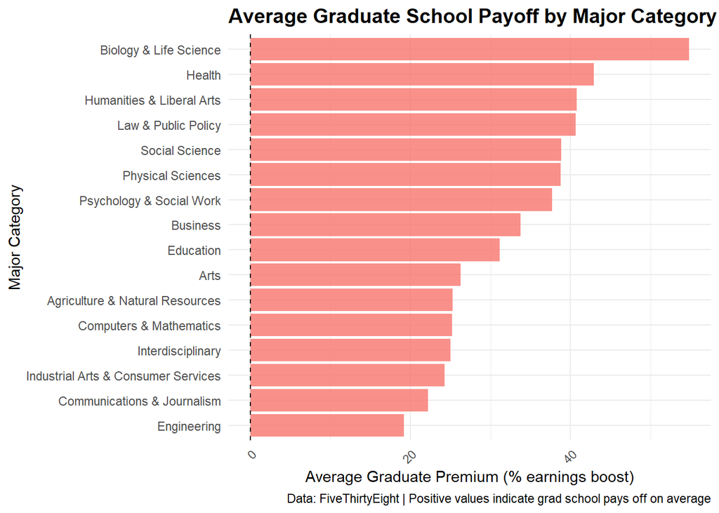

```r
category_avg <- earnings_enhanced %>%
  group_by(major_category_all) %>%
  summarize(
    avg_grad_premium = mean(grad_premium, na.rm = TRUE) * 100,
    .groups = "drop"
  ) %>%
  arrange(desc(avg_grad_premium))

ggplot(category_avg, aes(x = reorder(major_category_all, avg_grad_premium),
                          y = avg_grad_premium,
                          fill = avg_grad_premium > 0)) +
  geom_col(alpha = 0.8) +
  geom_hline(yintercept = 0, linetype = "dashed", color = "black") +
  labs(
    title = "Average Graduate School Payoff by Major Category",
    x = "Major Category",
    y = "Average Graduate Premium (% earnings boost)",
    caption = "Data: FiveThirtyEight | Positive values indicate grad school pays off on average"
  ) +
  theme_minimal() +
  theme(
    axis.text.x = element_text(angle = 45, hjust = 1),
    legend.position = "none",
    plot.title = element_text(size = 14, face = "bold")
  ) +
  coord_flip()
```

#### What can we learn from this chart?

# Conclusion

In this tutorial we completed a full data wrangling workflow.

What we accomplished:

1. We cleaned the data using filter() and removed the Food Science major with the missing data. Missing values can break calculations or bias results
2. We used select() to choose relevant columns for analysis. Too many columns make analysis confusing and slow.
3. We used left_join() to merge three datasets using the key major_code. Data is often split across multiple files.
4. We used mutate() with ifelse() to make new variables. Raw data doesn’t always have the metrics we need but we can make many of them using calculations or by combining data points.
5. We used filter() to find top performing majors. We use this to focus on the most interesting information. It helps narrow things down.
6. We used arrange() to sort data by earnings. This makes it easy to see highest and lowest values and get rankings or orders.
7. We used summarize() and group_by() to calculate statistics by major. We can’t always see everything at the individual level.
8. We used slice_max(), count(), and distinct() to save time and code.
9. We used ggplot() to make a nice plot of our data. Pictures help communicate findings clearly.

## What did we learn?

- How to identify and handle missing data
- How to join more than two datasets using a common key
- How to manipulate and summarize data
- How to create new variables and focused datasets
- How to ask questions and visualize our answers

This workflow can be applied to any data analysis project. The skills you’ve learned here like cleaning, joining, transforming, and visualizing are the foundation of effective data analysis.

[^1]: https://fivethirtyeight-r.netlify.app/articles/tame
[^2]: https://forum.posit.co/t/left-joining-multiple-tables-using-suffix-argument/207852/2